# RepData_PeerAssessment

Me

06/12/2020

## Reproducible data Peer ASsessment

First, load the data into R, and change the format of the date to date format. Take a look at the first few lines.

Then, use the aggregate function to get total steps per day Take a look at the first few lines of this too.

```r
myData<-read.csv("activity.csv")
head(myData)
```

```
##   steps       date interval
## 1    NA 2012-10-01        0
## 2    NA 2012-10-01        5
## 3    NA 2012-10-01       10
## 4    NA 2012-10-01       15
## 5    NA 2012-10-01       20
## 6    NA 2012-10-01       25
```

```r
myData$date<-as.Date(myData$date)

TotalByDay<- aggregate(myData$steps, list(Date = myData$date), FUN = sum, na.rm = TRUE)
head(TotalByDay)
```

```
##         Date     x
## 1 2012-10-01     0
## 2 2012-10-02   126
## 3 2012-10-03 11352
## 4 2012-10-04 12116
## 5 2012-10-05 13294
## 6 2012-10-06 15420
```

## Histogram to show the total number of steps per day

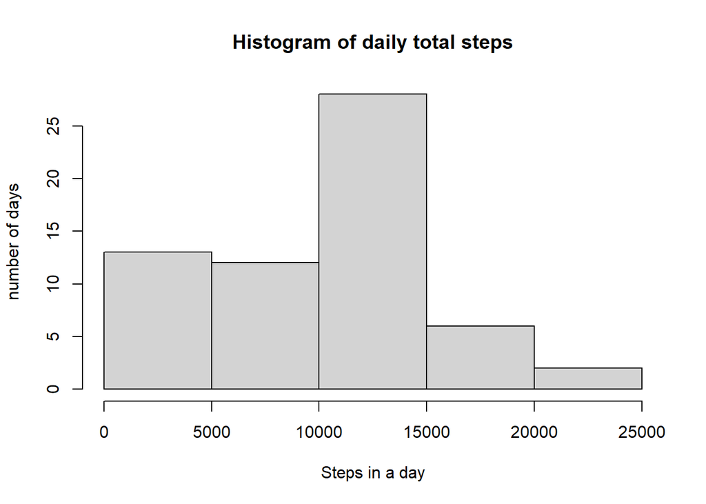

```r
hist(TotalByDay$x, xlab = "Steps in a day", ylab = "number of days" ,main = "Histogram of daily total steps")
```

## Mean of steps per day

```r
x<-format(mean(TotalByDay$x, na.rm = TRUE), scientific = FALSE)
```

The mean of steps per day is 9354.23

## Median of steps per day

```r
y<-format(median(TotalByDay$x, na.rm = TRUE), scientific = FALSE)
```

The median of steps per day is 10395

## Average number of steps by day

(I wasn’t clear what is meant by this request - average steps per interval for each day? This will just mirror total steps per day? But can’t think what else is being asked for…)

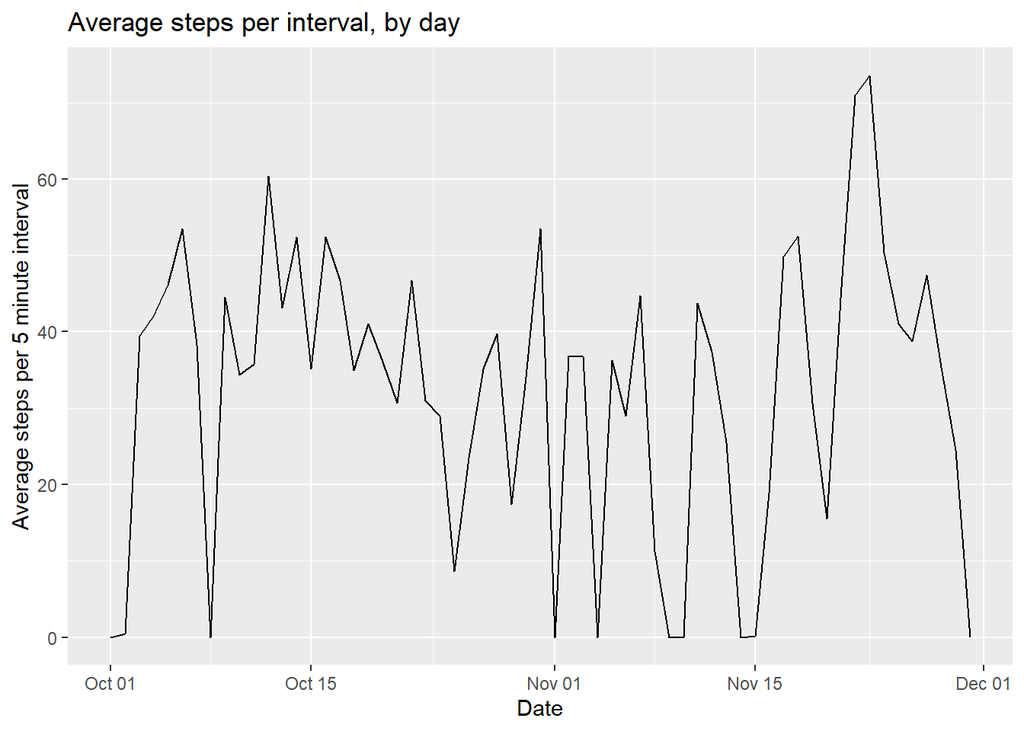

```r
library(ggplot2)
TotalByDay$av<-TotalByDay$x/288
 ggplot(data=TotalByDay, aes(x=Date, y = av)) + geom_line() + labs(title = "Average steps per interval, by day", x = "Date", y = "Average steps per 5 minute interval")
```

##which interval has the maximum number of steps, across all days?

Plot total steps across time period, by interval.

```r
TotalByInterval<- aggregate(myData$steps, list(Interval = myData$interval), FUN = sum, na.rm = TRUE)
TotalByInterval$av<-TotalByInterval$x
head(TotalByInterval)
```

```
##   Interval   x  av
## 1        0  91  91
## 2        5  18  18
## 3       10   7   7
## 4       15   8   8
## 5       20   4   4
## 6       25 111 111
```

```r
summary(TotalByInterval)
```

```
##     Interval            x                 av
##  Min.   :   0.0   Min.   :    0.0   Min.   :    0.0
##  1st Qu.: 588.8   1st Qu.:  131.8   1st Qu.:  131.8
##  Median :1177.5   Median : 1808.0   Median : 1808.0
##  Mean   :1177.5   Mean   : 1981.3   Mean   : 1981.3
##  3rd Qu.:1766.2   3rd Qu.: 2800.2   3rd Qu.: 2800.2
##  Max.   :2355.0   Max.   :10927.0   Max.   :10927.0
```

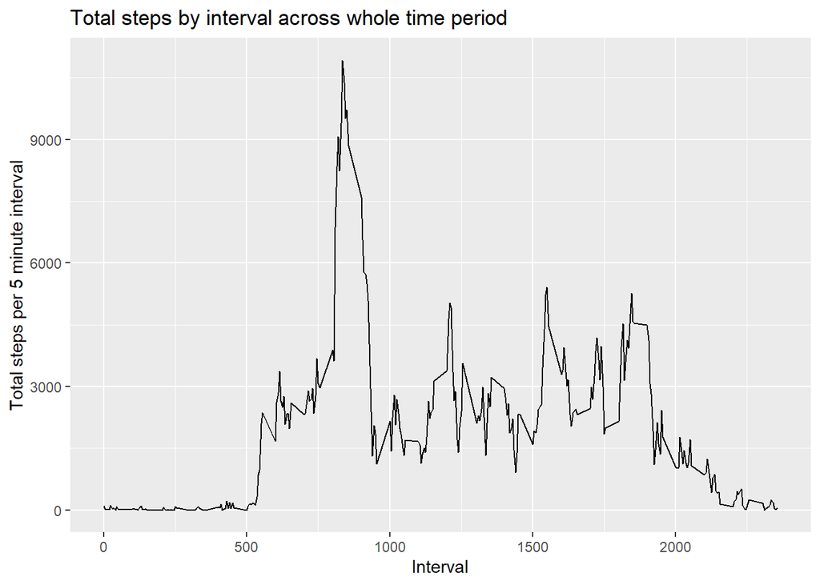

```r
 ggplot(data=TotalByInterval, aes(x=Interval, y = x)) + geom_line() + labs(title = "Total steps by interval across whole time period", x = "Interval", y = "Total steps per 5 minute interval")
```

```r
 maxMe<-which.max(TotalByInterval$x)
maxInt <- TotalByInterval[maxMe,]$Interval
print(maxInt)
```

```
## [1] 835
```

The interval with the most steps is 835